# CH7 Exercises

Ben Jones

30 September 2019

*7E1 a) heat b) socioeconomic background c) oxygen

*7E2 1) yes - heat and dryness interact 2) cylinders fuel injector - no interaction 3) interaction 4) interaction

*7E3 1) $C_i = \alpha + \beta_H H_i + \beta_D D_i + \beta_{HD} H_i D_i$ 2) $S_i = \alpha + \beta_C C_i + \beta_F F_i$ 3) $P_i = \alpha + \beta_{Pa} Pa_i + \beta_F F_i + \beta_{PaF} Pa_i F_i$ 4) $I_i = \alpha + \beta_S S_i + \beta_A A_i + \beta_{SA} S_i A_i$

*7M1 The interaction between shade, water and temperature is such that when temerature is warm there is no effect from either shade or from water, but when temperature is lower the effect of water and temperature is evident. This means that regardless of water and shade conditions, temperature must be low in order to produce blooms.

*7M2 Let $T_i = 0$ if temperature is hot. Then $B_i = T_i(\alpha + \beta_W W_i + \beta_S S_i + \beta_{SW}S_i W_i)$

*7M3 We postulate that raven population is positively associated with wolf population. However it is also likely that there is an interaction between wolf population and availability of prey. As a model

$R_i = \alpha + \beta_W W_i + \beta_P P_i + \beta_{WP}W_i P_i$ As in the absence of prey, wolves will not be able to feed as much, meaning both fewer wolves and thus fewer ravens.

*7H1

```r
library(rethinking)
data(tulips)
d <- tulips
```

```r
d$bedb <- ifelse(d$bed == "b",1,0)
d$bedc <- ifelse(d$bed == "c",1,0)
d$water.c = d$water - mean(d$water)
d$shade.c = d$shade - mean(d$shade)

m1 <- map(
  alist(
    blooms ~ dnorm(mu, sigma),
    mu <- a + bW * water.c + bS * shade.c + bB * bedb + bC * bedc + bWS * water.c * shade.c,
    a ~ dnorm(130,100),
    bW ~ dnorm(0,100),
    bS ~ dnorm(0, 100),
    bB ~ dnorm(0, 100),
    bC ~ dnorm(0, 100),
    bWS ~ dnorm(0,100),
    sigma ~ dunif(0, 100)
  ), data = d,
  start = list(a = mean(d$blooms), bW = 0, bS = 0, bB = 0, bC = 0, bWS = 0, sigma = sd(d$blooms))
  )

m2 <- map(
  alist(
    blooms ~ dnorm(mu, sigma),
    mu <- a + bW * water.c + bS * shade.c + bWS * water.c * shade.c,
    a ~ dnorm(130,100),
    bW ~ dnorm(0,100),
    bS ~ dnorm(0, 100),
    bWS ~ dnorm(0,100),
    sigma ~ dunif(0, 100)
  ), data = d,
  start = list(a = mean(d$blooms), bW = 0, bS = 0, bWS = 0, sigma = sd(d$blooms))
  )
```

*7H2

```r
compare(m1,m2)
```

```
##     WAIC pWAIC dWAIC weight    SE dSE
## m2 295.5   6.3   0.0   0.55 10.18  NA
## m1 295.9  10.3   0.4   0.45 10.30 7.8
```

```r
coeftab(m1,m2)
```

```
##       m1      m2
## a       99.36  129.01
## bW      75.12   74.96
## bS     -41.23  -41.14
## bB      42.41      NA
## bC      47.03      NA
## bWS    -52.15  -51.87
## sigma   39.19   45.22
## nobs       27      27
```

```r
post <- extract.samples(m1)
head(post)
```

```
##           a       bW        bS       bB       bC       bWS    sigma
## 1  80.31956 85.09411 -28.38542 60.81204 75.53115 -38.39805 45.06679
## 2 100.92858 70.96117 -24.21588 39.73549 45.94961 -58.09716 39.28774
## 3  93.49931 64.86907 -30.49538 67.64193 49.59947 -67.74441 43.95993
## 4  88.45348 80.67130 -44.63283 68.62655 53.53900 -53.81256 38.72341
## 5  96.17213 79.83780 -33.29883 45.81427 49.89331 -40.28116 45.63570
## 6  91.02641 86.02964 -43.28538 29.86362 57.30685 -60.61345 42.68403
```

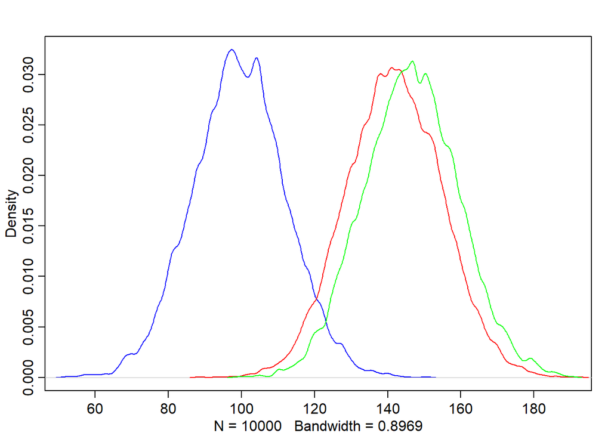

```r
postA <- post$a
postB <- post$a + post$bB
postC <- post$a + post$bC
dens(postA, col = "blue", xlim = c(min(postA),max(postC)))
dens(postB, col = "red", add = T)
dens(postC, col = "green", add = T)
```

We can see that B and C had a similar number of blooms, which were both substantially more than bed A.

*7H3

```r
data(rugged)
d <- rugged
d <- d[complete.cases(d$rgdppc_2000),]
d$lgdp <- log(d$rgdppc_2000)
d2 <- d[d$country != "Seychelles",]
m3 <- map(
  alist(
    lgdp ~ dnorm(mu, sigma),
    mu <- a + bA * cont_africa + bR * rugged + bAR * cont_africa * rugged,
    a ~ dnorm(8,100),
    bA ~ dnorm(0,1),
    bR ~ dnorm(0,1),
    bAR ~ dnorm(0,1),
    sigma ~ dunif(0,10)
  ),
  data = d
)

m4 <- map(
  alist(
    lgdp ~ dnorm(mu, sigma),
    mu <- a + bA * cont_africa + bR * rugged + bAR * cont_africa * rugged,
    a ~ dnorm(8,100),
    bA ~ dnorm(0,1),
    bR ~ dnorm(0,1),
    bAR ~ dnorm(0,1),
    sigma ~ dunif(0,10)
  ),
  data = d2
)

coeftab(m3,m4)
```

```
##       m3      m4
## a        9.18    9.19
## bA      -1.85   -1.78
## bR      -0.18   -0.19
## bAR      0.35    0.25
## sigma    0.93    0.93
## nobs      170     169
```

```r
precis(m3)
```

```
##        Mean StdDev  5.5% 94.5%
## a      9.18   0.14  8.97  9.40
## bA    -1.85   0.22 -2.20 -1.50
## bR    -0.18   0.08 -0.31 -0.06
## bAR    0.35   0.13  0.14  0.55
## sigma  0.93   0.05  0.85  1.01
```

```r
precis(m4)
```

```
##        Mean StdDev  5.5% 94.5%
## a      9.19   0.14  8.97  9.40
## bA    -1.78   0.22 -2.13 -1.43
## bR    -0.19   0.08 -0.31 -0.07
## bAR    0.25   0.14  0.04  0.47
## sigma  0.93   0.05  0.85  1.01
```

1. The interaction term has gotten smaller bu remains fairly convincingly above zero in the limits of the credible interval.

```r
rugged.seq <- seq(from = -1, to =  8, by = 0.25)
mu.Africa <- link(m3, data = data.frame(cont_africa = 1, rugged = rugged.seq))
```

```
## [ 100 / 1000 ]
[ 200 / 1000 ]
[ 300 / 1000 ]
[ 400 / 1000 ]
[ 500 / 1000 ]
[ 600 / 1000 ]
[ 700 / 1000 ]
[ 800 / 1000 ]
[ 900 / 1000 ]
[ 1000 / 1000 ]
```

```r
mu.Africa.mean <- apply(mu.Africa, 2, mean)
mu.Africa.PI <- apply(mu.Africa,2,PI, prob = 0.97)

mu.NotAfrica <- link(m3, data = data.frame(cont_africa = 0, rugged = rugged.seq))
```

```
## [ 100 / 1000 ]
[ 200 / 1000 ]
[ 300 / 1000 ]
[ 400 / 1000 ]
[ 500 / 1000 ]
[ 600 / 1000 ]
[ 700 / 1000 ]
[ 800 / 1000 ]
[ 900 / 1000 ]
[ 1000 / 1000 ]
```

```r
mu.NotAfrica.mean <- apply(mu.NotAfrica, 2, mean)
mu.NotAfrica.PI <- apply(mu.NotAfrica,2,PI, prob = 0.97)

mu.AfricaS <- link(m4, data = data.frame(cont_africa = 1, rugged = rugged.seq))
```

```
## [ 100 / 1000 ]
[ 200 / 1000 ]
[ 300 / 1000 ]
[ 400 / 1000 ]
[ 500 / 1000 ]
[ 600 / 1000 ]
[ 700 / 1000 ]
[ 800 / 1000 ]
[ 900 / 1000 ]
[ 1000 / 1000 ]
```

```r
mu.AfricaS.mean <- apply(mu.AfricaS, 2, mean)
mu.AfricaS.PI <- apply(mu.AfricaS,2,PI, prob = 0.97)

mu.NotAfricaS <- link(m4, data = data.frame(cont_africa = 0, rugged = rugged.seq))
```

```
## [ 100 / 1000 ]
[ 200 / 1000 ]
[ 300 / 1000 ]
[ 400 / 1000 ]
[ 500 / 1000 ]
[ 600 / 1000 ]
[ 700 / 1000 ]
[ 800 / 1000 ]
[ 900 / 1000 ]
[ 1000 / 1000 ]
```

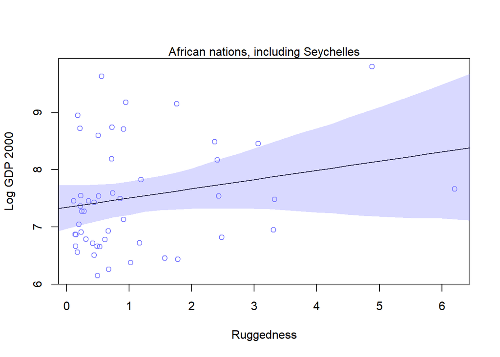

```r
mu.NotAfricaS.mean <- apply(mu.NotAfricaS, 2, mean)
mu.NotAfricaS.PI <- apply(mu.NotAfricaS,2,PI, prob = 0.97)

d.A1 <- d[d$cont_africa == 1,]
plot(lgdp ~ rugged, data = d.A1,
      col = rangi2, ylab = "Log GDP 2000", xlab = "Ruggedness")
mtext("African nations, including Seychelles")
lines(rugged.seq, mu.Africa.mean)
shade(mu.Africa.PI, rugged.seq, col = col.alpha(rangi2,0.3))
```

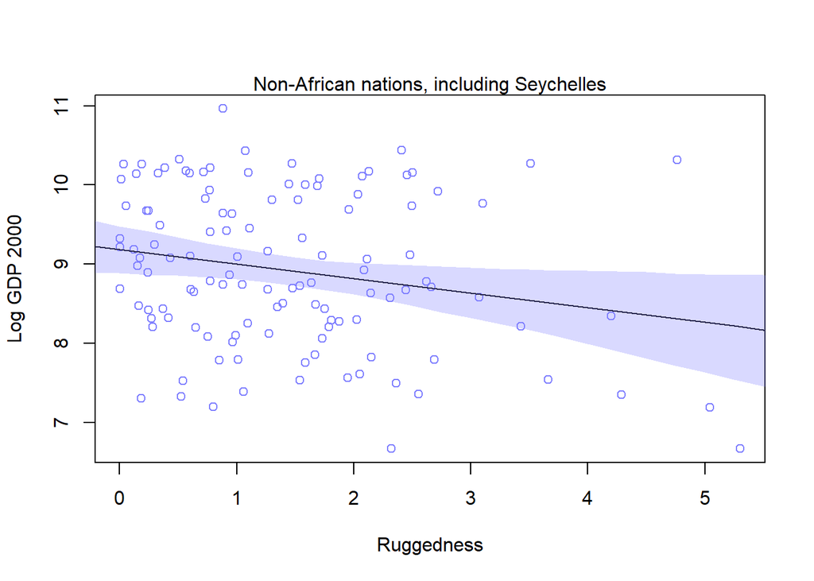

```r
d.A0 <- d[d$cont_africa == 0,]
plot(lgdp ~ rugged, data = d.A0,
      col = rangi2, ylab = "Log GDP 2000", xlab = "Ruggedness")
mtext("Non-African nations, including Seychelles")
lines(rugged.seq, mu.NotAfrica.mean)
shade(mu.NotAfrica.PI, rugged.seq, col = col.alpha(rangi2,0.3))
```

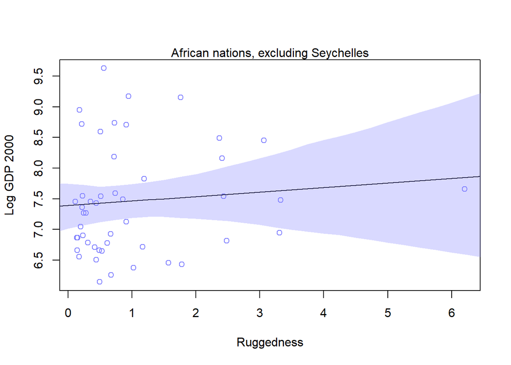

```r
d2.A1 <- d2[d2$cont_africa == 1,]
plot(lgdp ~ rugged, data = d2.A1,
      col = rangi2, ylab = "Log GDP 2000", xlab = "Ruggedness")
mtext("African nations, excluding Seychelles")
lines(rugged.seq, mu.AfricaS.mean)
shade(mu.AfricaS.PI, rugged.seq, col = col.alpha(rangi2,0.3))
```

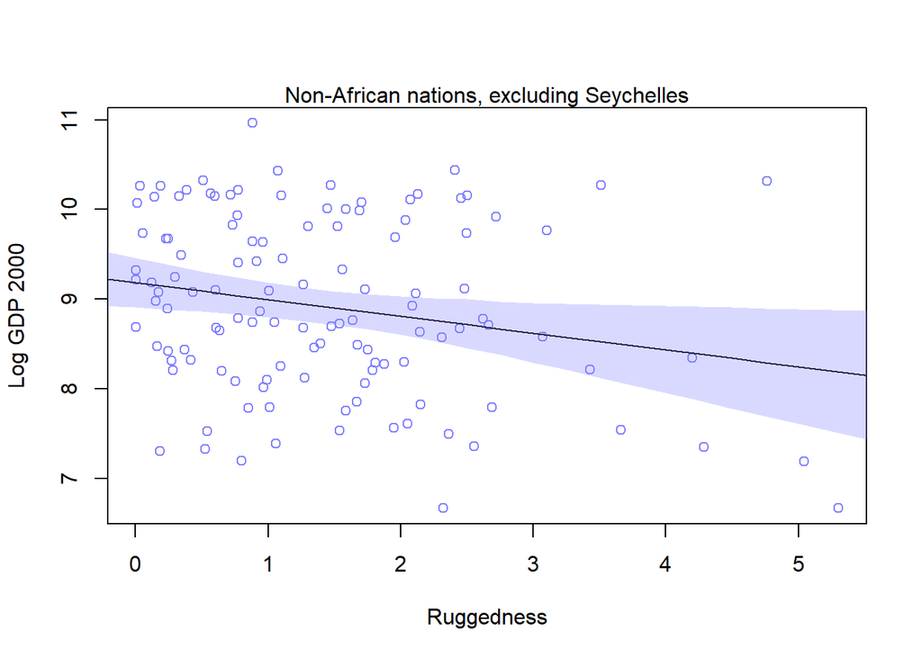

```r
d2.A0 <- d2[d2$cont_africa == 0,]
plot(lgdp ~ rugged, data = d2.A0,
      col = rangi2, ylab = "Log GDP 2000", xlab = "Ruggedness")
mtext("Non-African nations, excluding Seychelles")
lines(rugged.seq, mu.NotAfricaS.mean)
shade(mu.NotAfricaS.PI, rugged.seq, col = col.alpha(rangi2,0.3))
```

Without the Seychelles the slope for the african nations is slightly less steep and more uncertain at the higher levels of ruggedness, but the relationship does remain.

```r
m5 <- map(alist(
  lgdp ~ dnorm(mu, sigma),
  mu <- a + bR * rugged,
  a ~ dnorm(8, 100),
  bR ~ dnorm(0, 1),
  sigma ~ dunif(0, 10)
), data = d2
)

m6 <- map(alist(
  lgdp ~ dnorm(mu, sigma),
  mu <- a + bA * cont_africa + bR * rugged,
  a ~ dnorm(8, 100),
  bA ~ dnorm(0, 1),
  bR ~ dnorm(0,1),
  sigma ~ dunif(0,10)
), data = d2)

m7 <- map(alist(
  lgdp ~ dnorm(mu, sigma),
  mu <- a + bA * cont_africa + bR * rugged + bAR * rugged * cont_africa,
  a ~ dnorm(8, 100),
  bA ~ dnorm(0, 1),
  bR ~ dnorm(0,1),
  bAR ~ dnorm(0,1),
  sigma ~ dunif(0,10)
), data = d2)

compare(m5,m6,m7)
```

```
##     WAIC pWAIC dWAIC weight    SE   dSE
## m7 463.7   4.8   0.0   0.79 15.05    NA
## m6 466.3   4.0   2.6   0.21 14.31  3.23
## m5 535.9   2.5  72.2   0.00 13.32 15.18
```

The majority of the weight is given to the model which includes the interaction term. None is given to the model which only includes ruggedness.

Now do the same for the data, including the Seychelles

```r
m8 <- map(alist(
  lgdp ~ dnorm(mu, sigma),
  mu <- a + bR * rugged,
  a ~ dnorm(8, 100),
  bR ~ dnorm(0, 1),
  sigma ~ dunif(0, 10)
), data = d
)

m9 <- map(alist(
  lgdp ~ dnorm(mu, sigma),
  mu <- a + bA * cont_africa + bR * rugged,
  a ~ dnorm(8, 100),
  bA ~ dnorm(0, 1),
  bR ~ dnorm(0,1),
  sigma ~ dunif(0,10)
), data = d)

m10 <- map(alist(
  lgdp ~ dnorm(mu, sigma),
  mu <- a + bA * cont_africa + bR * rugged + bAR * rugged * cont_africa,
  a ~ dnorm(8, 100),
  bA ~ dnorm(0, 1),
  bR ~ dnorm(0,1),
  bAR ~ dnorm(0,1),
  sigma ~ dunif(0,10)
), data = d)
compare(m8,m9,m10)
```

```
##      WAIC pWAIC dWAIC weight    SE   dSE
## m10 470.0   5.5   0.0   0.96 15.14    NA
## m9  476.6   4.4   6.6   0.04 15.32  6.25
## m8  539.4   2.6  69.4   0.00 13.29 15.21
```

The model with Seychelles includes even more weight for the interaction model than that without Seychelles.

```r
dA.predict = list(lgdp = rep(0,37),
                  rugged = rugged.seq,
                  cont_africa = rep(1,37)
                  )

dNA.predict = list(lgdp = rep(0,37),
                    rugged = rugged.seq,
                    cont_africa = rep(0,37))


ruggedness.ensembleNSA <- ensemble(m5,m6,m7,data=dA.predict)
```

```
## Constructing posterior predictions
```

```
## [ 100 / 1000 ]
[ 200 / 1000 ]
[ 300 / 1000 ]
[ 400 / 1000 ]
[ 500 / 1000 ]
[ 600 / 1000 ]
[ 700 / 1000 ]
[ 800 / 1000 ]
[ 900 / 1000 ]
[ 1000 / 1000 ]
```

```
## Constructing posterior predictions
```

```
## [ 100 / 1000 ]
[ 200 / 1000 ]
[ 300 / 1000 ]
[ 400 / 1000 ]
[ 500 / 1000 ]
[ 600 / 1000 ]
[ 700 / 1000 ]
[ 800 / 1000 ]
[ 900 / 1000 ]
[ 1000 / 1000 ]
```

```
## Constructing posterior predictions
```

```
## [ 100 / 1000 ]
[ 200 / 1000 ]
[ 300 / 1000 ]
[ 400 / 1000 ]
[ 500 / 1000 ]
[ 600 / 1000 ]
[ 700 / 1000 ]
[ 800 / 1000 ]
[ 900 / 1000 ]
[ 1000 / 1000 ]
```

```r
ruggedness.ensembleNSNA <- ensemble(m5,m6,m7,data=dNA.predict)
```

```
## Constructing posterior predictions
```

```
## [ 100 / 1000 ]
[ 200 / 1000 ]
[ 300 / 1000 ]
[ 400 / 1000 ]
[ 500 / 1000 ]
[ 600 / 1000 ]
[ 700 / 1000 ]
[ 800 / 1000 ]
[ 900 / 1000 ]
[ 1000 / 1000 ]
```

```
## Constructing posterior predictions
```

```
## [ 100 / 1000 ]
[ 200 / 1000 ]
[ 300 / 1000 ]
[ 400 / 1000 ]
[ 500 / 1000 ]
[ 600 / 1000 ]
[ 700 / 1000 ]
[ 800 / 1000 ]
[ 900 / 1000 ]
[ 1000 / 1000 ]
```

```
## Constructing posterior predictions
```

```
## [ 100 / 1000 ]
[ 200 / 1000 ]
[ 300 / 1000 ]
[ 400 / 1000 ]
[ 500 / 1000 ]
[ 600 / 1000 ]
[ 700 / 1000 ]
[ 800 / 1000 ]
[ 900 / 1000 ]
[ 1000 / 1000 ]
```

```r
#Africa, no seychelles
mu.AfricaNS <- apply(ruggedness.ensembleNSA$link, 2, mean)
PI.AfricaNS <- apply(ruggedness.ensembleNSA$link, 2, PI, prob = 0.97)
#not Africa, no Seychelles
mu.NAfricaNS <- apply(ruggedness.ensembleNSNA$link, 2, mean)
PI.NAfricaNS <- apply(ruggedness.ensembleNSNA$link, 2, PI, prob = 0.97)

ruggedness.ensembleAS <- ensemble(m8,m9,m10, data = dA.predict)
```

```
## Constructing posterior predictions
```

```
## [ 100 / 1000 ]
[ 200 / 1000 ]
[ 300 / 1000 ]
[ 400 / 1000 ]
[ 500 / 1000 ]
[ 600 / 1000 ]
[ 700 / 1000 ]
[ 800 / 1000 ]
[ 900 / 1000 ]
[ 1000 / 1000 ]
```

```
## Constructing posterior predictions
```

```
## [ 100 / 1000 ]
[ 200 / 1000 ]
[ 300 / 1000 ]
[ 400 / 1000 ]
[ 500 / 1000 ]
[ 600 / 1000 ]
[ 700 / 1000 ]
[ 800 / 1000 ]
[ 900 / 1000 ]
[ 1000 / 1000 ]
```

```
## Constructing posterior predictions
```

```
## [ 100 / 1000 ]
[ 200 / 1000 ]
[ 300 / 1000 ]
[ 400 / 1000 ]
[ 500 / 1000 ]
[ 600 / 1000 ]
[ 700 / 1000 ]
[ 800 / 1000 ]
[ 900 / 1000 ]
[ 1000 / 1000 ]
```

```r
ruggedness.ensembleNAS <- ensemble(m8, m9, m10, data = dA.predict)
```

```
## Constructing posterior predictions
```

```
## [ 100 / 1000 ]
[ 200 / 1000 ]
[ 300 / 1000 ]
[ 400 / 1000 ]
[ 500 / 1000 ]
[ 600 / 1000 ]
[ 700 / 1000 ]
[ 800 / 1000 ]
[ 900 / 1000 ]
[ 1000 / 1000 ]
```

```
## Constructing posterior predictions
```

```
## [ 100 / 1000 ]
[ 200 / 1000 ]
[ 300 / 1000 ]
[ 400 / 1000 ]
[ 500 / 1000 ]
[ 600 / 1000 ]
[ 700 / 1000 ]
[ 800 / 1000 ]
[ 900 / 1000 ]
[ 1000 / 1000 ]
```

```
## Constructing posterior predictions
```

```
## [ 100 / 1000 ]
[ 200 / 1000 ]
[ 300 / 1000 ]
[ 400 / 1000 ]
[ 500 / 1000 ]
[ 600 / 1000 ]
[ 700 / 1000 ]
[ 800 / 1000 ]
[ 900 / 1000 ]
[ 1000 / 1000 ]
```

[figure not shown]

```r
#Africa, Seychelles
mu.AfricaS <- apply(ruggedness.ensembleAS$link, 2, mean)
PI.AfricaS <- apply(ruggedness.ensembleAS$link, 2, PI, prob = 0.97)

#No africa, seychelles
mu.NAfricaS <- apply(ruggedness.ensembleNAS$link, 2, mean)
PI.NAfricaS <- apply(ruggedness.ensembleNAS$link,2,PI,prob = 0.97)

par(mfrow = c(2,2))
#Africa, no seychelles
plot(lgdp~rugged, col = rangi2, data = d2[d2$cont_africa == 1,])
lines(rugged.seq, mu.AfricaNS)
shade(PI.AfricaNS, rugged.seq)
mtext("Africa, no Seychelles")
#Not africa, no Seychelles
plot(lgdp ~ rugged, col = rangi2, data = d2[d2$cont_africa == 0,])
lines(rugged.seq, mu.NAfricaNS)
shade(PI.NAfricaNS, rugged.seq)
mtext("Not africa, no seychelles")
#Africa, with seychelles
plot(lgdp ~ rugged, col = rangi2, data = d[d$cont_africa == 1,])
lines(rugged.seq, mu.AfricaS)
shade(PI.AfricaS, rugged.seq)
mtext("Africa, with seychelles")
#Not africa, with seychelles
plot(lgdp ~ rugged, col = rangi2, data = d[d$cont_africa == 0,])
lines(rugged.seq, mu.NAfricaS)
shade(PI.NAfricaS, rugged.seq)
mtext("Not africa, with seychelles")
```

When we exclude the seychelles from the ensemble, we see even less inteaction effect, as more weight is given to the model without interaction effect.

*7H4

```r
data(nettle)
d <- nettle

d$lang.per.cap <- d$num.lang/d$k.pop
d$llang.per.cap <- log(d$lang.per.cap)
d$larea <- log(d$area)

m1 <- map(
  alist(
    llang.per.cap ~ dnorm(mu, sigma),
    mu <- a + bG * mean.growing.season + bA * larea,
    a ~ dnorm(-5,5),
    bG ~ dnorm(0,5),
    bA ~ dnorm(0,5),
    sigma ~ dunif(0,10)
  ), data =d
)
precis(m1)
```

```
##        Mean StdDev  5.5% 94.5%
## a     -3.99   1.83 -6.92 -1.07
## bG     0.15   0.05  0.06  0.23
## bA    -0.19   0.13 -0.40  0.01
## sigma  1.39   0.11  1.21  1.57
```

The coefficient for growing season is positively associated with languages per capita, and the confidence region is comfortably above 0, providing evidence of a positive reltionship that growing season increases the languages per capita. b)

```r
m2 <- map(
  alist(
    llang.per.cap ~ dnorm(mu, sigma),
    mu <- a + bS * sd.growing.season + bA * larea,
    a ~ dnorm(-5,5),
    bS ~ dnorm(0,5),
    bA ~ dnorm(0,5),
    sigma ~ dunif(0,10)
  ), data = d
)
precis(m2)
```

```
##        Mean StdDev  5.5% 94.5%
## a     -2.37   1.76 -5.18  0.44
## bS    -0.22   0.18 -0.52  0.07
## bA    -0.21   0.15 -0.44  0.02
## sigma  1.44   0.12  1.25  1.63
```

Whilst the coefficient for sd of growing season is negative, this estimate is not convinvingly below zero and so doesn’t provide convincing evidence of a negative association.

```r
m3 <- map(
  alist(
    llang.per.cap ~ dnorm(mu, sigma),
    mu <- a + bS * sd.growing.season + bG * mean.growing.season + bSG * sd.growing.season * mean.growing.season + bA * larea,
    a ~ dnorm(-5,5),
    bS ~ dnorm(0,5),
    bG ~ dnorm(0,5),
    bSG ~ dnorm(0, 5),
    bA ~ dnorm(0, 5),
    sigma ~ dunif(0,10)
  ), data = d
)
precis(m3)
```

```
##        Mean StdDev  5.5% 94.5%
## a     -6.61   1.97 -9.76 -3.46
## bS     0.42   0.38 -0.19  1.04
## bG     0.29   0.07  0.17  0.41
## bSG   -0.11   0.05 -0.18 -0.03
## bA    -0.03   0.15 -0.26  0.21
## sigma  1.31   0.11  1.14  1.48
```

```r
compare(m1,m2,m3)
```

```
##     WAIC pWAIC dWAIC weight    SE  dSE
## m3 263.6   7.0   0.0    0.9 16.53   NA
## m1 268.0   4.8   4.4    0.1 15.90 5.44
## m2 274.4   5.6  10.8    0.0 17.23 6.59
```

Comparing the models, we can see that the vast majority of the weight is given to the model with an interaction term, implying that the interaction is important. We should produce some triptych plots to aid interpretation here.

First, we should discretise each of the variables into three, then fix them and predict the outcome whilst letting the other variable in the interaction vary. We can do this by standardising the variables

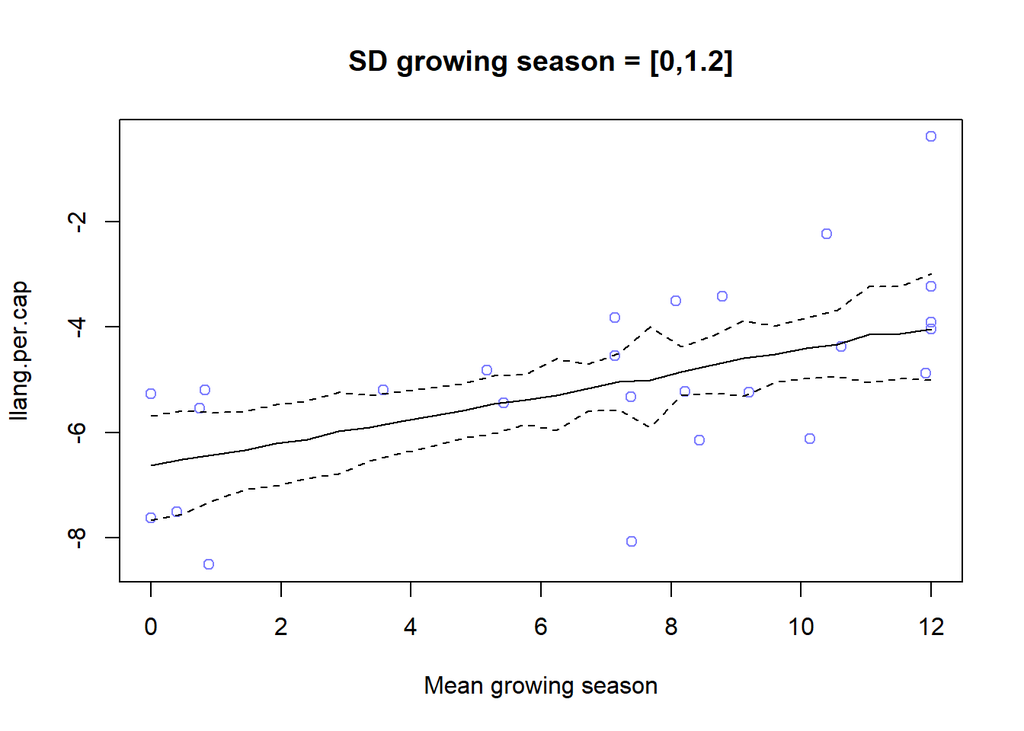

```
## [ 100 / 1000 ]
[ 200 / 1000 ]
[ 300 / 1000 ]
[ 400 / 1000 ]
[ 500 / 1000 ]
[ 600 / 1000 ]
[ 700 / 1000 ]
[ 800 / 1000 ]
[ 900 / 1000 ]
[ 1000 / 1000 ]
```

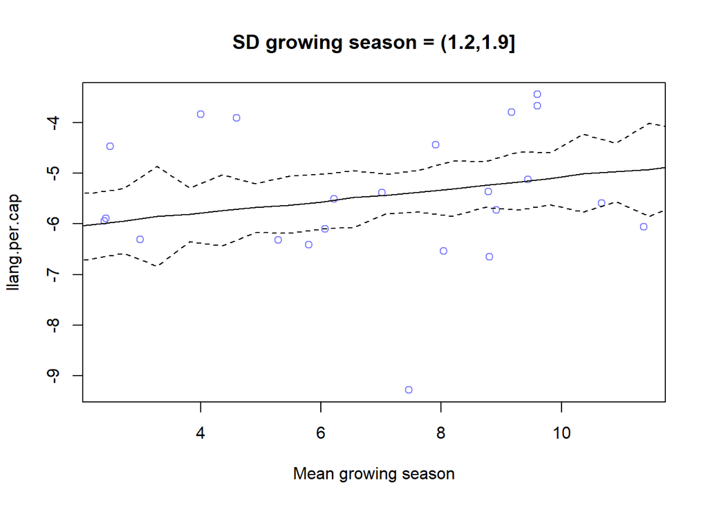

```
## [ 100 / 1000 ]
[ 200 / 1000 ]
[ 300 / 1000 ]
[ 400 / 1000 ]
[ 500 / 1000 ]
[ 600 / 1000 ]
[ 700 / 1000 ]
[ 800 / 1000 ]
[ 900 / 1000 ]
[ 1000 / 1000 ]
```

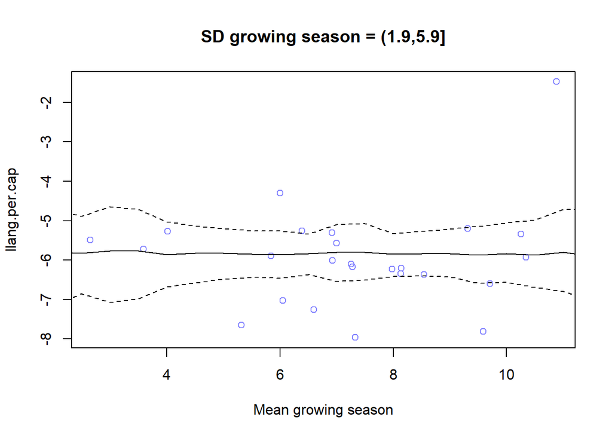

```
## [ 100 / 1000 ]
[ 200 / 1000 ]
[ 300 / 1000 ]
[ 400 / 1000 ]
[ 500 / 1000 ]
[ 600 / 1000 ]
[ 700 / 1000 ]
[ 800 / 1000 ]
[ 900 / 1000 ]
[ 1000 / 1000 ]
```

```r
d$sd.growing.season.c <- (d$sd.growing.season - mean(d$sd.growing.season))
d$SD.cut <- cut(
  d$sd.growing.season,
  breaks = quantile(d$sd.growing.season, prob = c(0,1/3,2/3,1)),
  include.lowest = T,
  dig.lab = 2
)
growing.seq <- seq(0,12,length.out = 74)
for(i in levels(d$SD.cut)){
  dt <- d[d$SD.cut == i,]
  plot(llang.per.cap ~ mean.growing.season, data = dt, col = rangi2,
       main = paste("SD growing season =", i), xlab = "Mean growing season")
  mu <- link(m3, data = data.frame(sd.growing.season = mean(dt$sd.growing.season), mean.growing.season = seq(0,12,length.out = nrow(dt)), larea = dt$larea))
  mu.mean <- apply(mu,2,mean)
  mu.PI <- apply(mu,2,PI, prob = 0.97)
  lines(seq(0,12,length.out = nrow(dt)), mu.mean)
  lines(seq(0,12,length.out = nrow(dt)), mu.PI[1,],lty = 2)
  lines(seq(0,12,length.out = nrow(dt)), mu.PI[2,], lty = 2)
}
```

From this we can infer that at lower SD growing seasons, mean growing season has a greater effect on languages per capita. This effect diminishes as sd of growing season gets larger.